# task15

Manvydas Sokolovas

20 May 2016

Užkraunamas “fpp” paketas:

```r
library("fpp")
```

### 1 užduotis:

Choose one of the following seasonal time series: condmilk, hsales, uselec

Naudojami “uselec” duomenys. Atvaizduojami grafiškai:

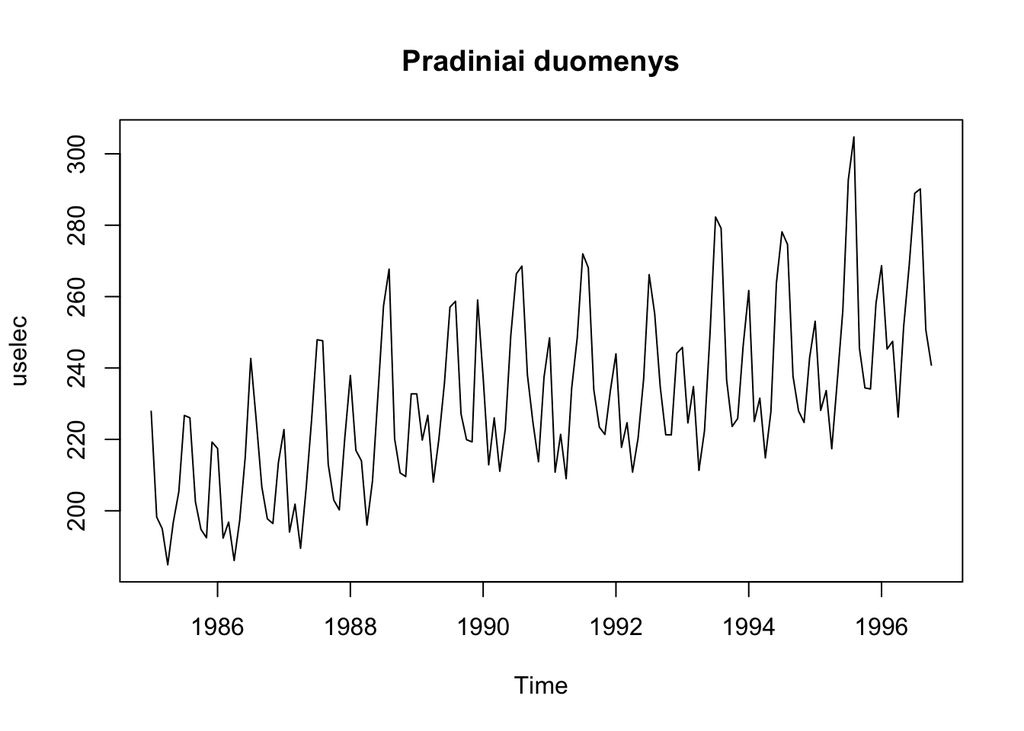

```r
plot(uselec, main = "Pradiniai duomenys")
```

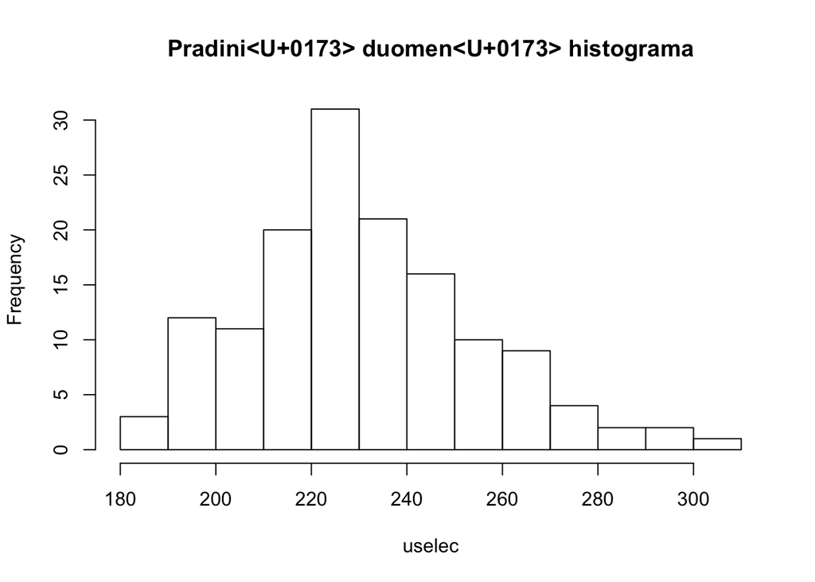

```r
hist(uselec, main = "Pradinių duomenų histograma")
```

- Duomenys yra sezoniški, turi kylantį trendą.
- Histograma panaši į normalaus skirstinio, tačiau atrodo nepakankamai. Atliksime duomenų transformaciją.

**(a) Do the data need transforming? If so, find a suitable transformation.**

```r
l <- BoxCox.lambda(uselec); l # Transformacijos lambda
```

```
## [1] -0.3468655
```

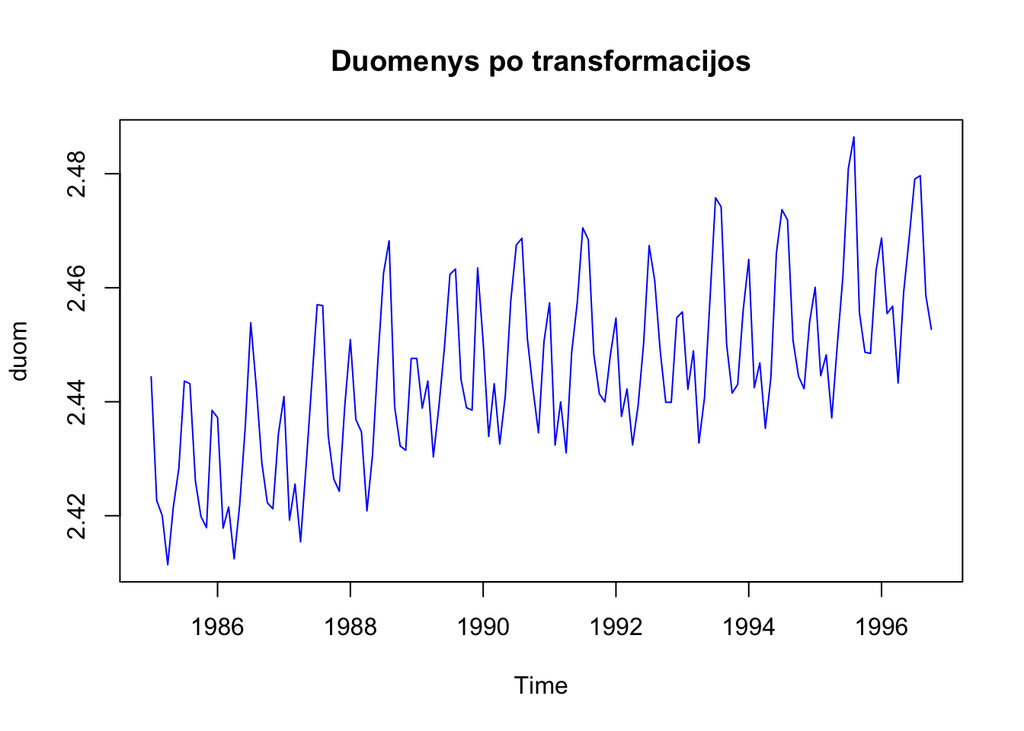

```r
duom <- BoxCox(uselec, lambda = l)
plot(duom, col = "blue", main = "Duomenys po transformacijos")
```

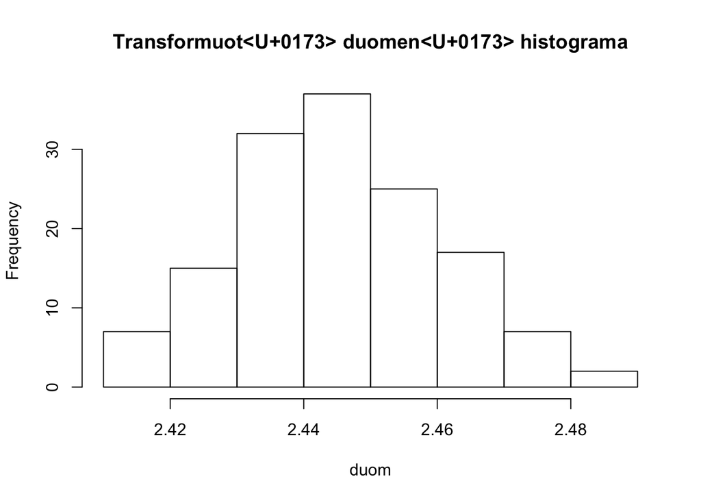

```r
hist(duom, main = "Transformuotų duomenų histograma")
```

- Duomenų transformacija sulygino duomenų svyravimus ir taip pat matome, jog transformuotų duomenų histograma panašesnė į normaliojo skirstinio.

**(b) Are the data stationary? If not, find an appropriate differencing which yields stationary data.**

```r
kpss.test(duom) # H0: duomenys yra stacionarūs
```

```
##
##  KPSS Test for Level Stationarity
##
## data:  duom
## KPSS Level = 2.5736, Truncation lag parameter = 2, p-value = 0.01
```

- p-value < 0.05, tai H0 hipotezė atmetama. Duomenys nėra stacionarūs.

```r
n <- nsdiffs(duom); n
```

```
## [1] 1
```

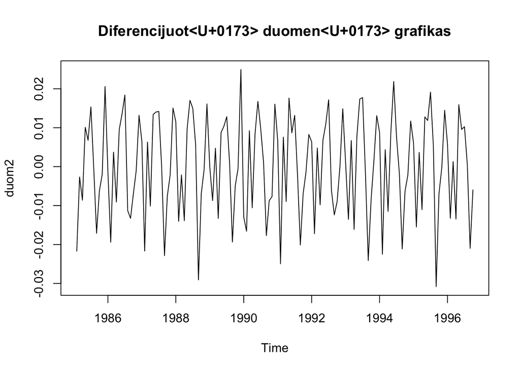

```r
duom2 <- diff(duom, diff = n)
plot(duom2, main = "Diferencijuotų duomenų grafikas")
```

```r
kpss.test(duom2) # H0: duomenys yra stacionarūs
```

```
##
##  KPSS Test for Level Stationarity
##
## data:  duom2
## KPSS Level = 0.0098762, Truncation lag parameter = 2, p-value =
## 0.1
```

- Duomenys nebeturi trendo, todėl panašu, jog yra stacionarūs. KPSS testas patvirtina, jog duomenys yra stacionarūs (p-value > 0.05, H0 priimama).